# Part I - San Francisco Bay Ford GoBike Service

## Introduction

This data set includes information about individual rides made in a bike-sharing system covering the greater San Francisco Bay area. This dataset includes information about individual rides made in a bike-sharing system covering the greater San Francisco Bay area.The Ford GoBike services is a bike sharing transportation provided by Ford that is easy to use, enjoyable and convenient. There are several bike stations, both start stations and end stations. People use bike sharing for many different reasons, such as commuting to work or school, running errands, and getting to and from appointments.The dataset contains the February 2019 records which has 183,412 records and 16 features. The dataset contains details of stations, duration of rides, gender, and types of users. The service has two types of users which are Customers and Subscribers. I am going to be carrying out exploratory and explanatory data analysis on the dataset.

## Preliminary Wrangling

```python
# import all packages and set plots to be embedded inline
import numpy as np
import pandas as pd
import matplotlib.pyplot as plt
import seaborn as sb
import datetime
import calendar
import math


%matplotlib inline
```

```python
#load the ford Go bike dataset
ford_df = pd.read_csv('201902-fordgobike-tripdata.csv')
```

```python
#view the dataset
ford_df.head()
```

|  | duration_sec | start_time | end_time | start_station_id | start_station_name | start_station_latitude | start_station_longitude | end_station_id | end_station_name | end_station_latitude | end_station_longitude | bike_id | user_type | member_birth_year | member_gender | bike_share_for_all_trip |
| --- | --- | --- | --- | --- | --- | --- | --- | --- | --- | --- | --- | --- | --- | --- | --- | --- |
| 0 | 52185 | 2019-02-28 17:32:10.1450 | 2019-03-01 08:01:55.9750 | 21.0 | Montgomery St BART Station (Market St at 2nd St) | 37.789625 | -122.400811 | 13.0 | Commercial St at Montgomery St | 37.794231 | -122.402923 | 4902 | Customer | 1984.0 | Male | No |
| 1 | 42521 | 2019-02-28 18:53:21.7890 | 2019-03-01 06:42:03.0560 | 23.0 | The Embarcadero at Steuart St | 37.791464 | -122.391034 | 81.0 | Berry St at 4th St | 37.775880 | -122.393170 | 2535 | Customer | NaN | NaN | No |
| 2 | 61854 | 2019-02-28 12:13:13.2180 | 2019-03-01 05:24:08.1460 | 86.0 | Market St at Dolores St | 37.769305 | -122.426826 | 3.0 | Powell St BART Station (Market St at 4th St) | 37.786375 | -122.404904 | 5905 | Customer | 1972.0 | Male | No |
| 3 | 36490 | 2019-02-28 17:54:26.0100 | 2019-03-01 04:02:36.8420 | 375.0 | Grove St at Masonic Ave | 37.774836 | -122.446546 | 70.0 | Central Ave at Fell St | 37.773311 | -122.444293 | 6638 | Subscriber | 1989.0 | Other | No |
| 4 | 1585 | 2019-02-28 23:54:18.5490 | 2019-03-01 00:20:44.0740 | 7.0 | Frank H Ogawa Plaza | 37.804562 | -122.271738 | 222.0 | 10th Ave at E 15th St | 37.792714 | -122.248780 | 4898 | Subscriber | 1974.0 | Male | Yes |

```python
#check the number of rows and columns in the dataset
ford_df.shape
```

```
(183412, 16)
```

```python
#check the information of the dataset
ford_df.info()
```

```
<class 'pandas.core.frame.DataFrame'>
RangeIndex: 183412 entries, 0 to 183411
Data columns (total 16 columns):
duration_sec               183412 non-null int64
start_time                 183412 non-null object
end_time                   183412 non-null object
start_station_id           183215 non-null float64
start_station_name         183215 non-null object
start_station_latitude     183412 non-null float64
start_station_longitude    183412 non-null float64
end_station_id             183215 non-null float64
end_station_name           183215 non-null object
end_station_latitude       183412 non-null float64
end_station_longitude      183412 non-null float64
bike_id                    183412 non-null int64
user_type                  183412 non-null object
member_birth_year          175147 non-null float64
member_gender              175147 non-null object
bike_share_for_all_trip    183412 non-null object
dtypes: float64(7), int64(2), object(7)
memory usage: 22.4+ MB
```

```python
#check for duplicate values
ford_df.duplicated().sum()
```

```
0
```

```python
#check for unique values in the user types in the dataset
ford_df['user_type'].unique()
```

```
array(['Customer', 'Subscriber'], dtype=object)
```

```python
#check for unique values in the member gender variable
ford_df['member_gender'].unique()
```

```
array(['Male', nan, 'Other', 'Female'], dtype=object)
```

```python
#check for unique values in the bike_share_for all_trips variable
ford_df['bike_share_for_all_trip'].unique()
```

```
array(['No', 'Yes'], dtype=object)
```

### What is the structure of your dataset?

The dataset contains 183412 rows and 16 columns.

### What is/are the main feature(s) of interest in your dataset?

> The main features of my interest in this dataset are
> - user types
> - member gender
> - member age
> - start_weekdays and period of day

### What features in the dataset do you think will help support your investigation into your feature(s) of interest?

> The features that would help me support my investigation into the features of my interest are start_station_name, usertype, start_time, member_birth_year, member_gender, duration, period_of_Day

### Observations from the dataset

I observed some quality and tidiness issues in the dataset which are going to be addressed before the exploratory analysis. Some of these issues include:

- Convert datatypes like the time variables, which are the start_time and end_time variables should be converted to datetime datatype instead of string datatype, the user_type, member_gender and bike_share_for_all_trip variables can be converted to categorical variables, bike_id can be converted to string datatype
- The start_time variable could be broken down further into hour of the day, day of the week, month of the year.
- Derive the age of the members from their birth year information

### Cleaning the dataset

```python
#make a copy of the dataset
ford_clean = ford_df.copy()
```

```python
#convert datatypes to correct datatypes

#start_time and end_time variables to datetime datatype
ford_clean['start_time'] = pd.to_datetime(ford_clean['start_time'])
ford_clean['end_time'] = pd.to_datetime(ford_clean['end_time'])

#user_type, member_gender, and bike_share_for_all_trip variables to categorical datatype
for col in ['member_gender', 'user_type', 'bike_share_for_all_trip']:
    ford_clean[col] = ford_clean[col].astype('category')

#bike_id variable to string datatype
ford_clean['bike_id'] = ford_clean['bike_id'].astype('object')
```

```python
#Test the changes
ford_clean.dtypes
```

```
duration_sec                        int64
start_time                 datetime64[ns]
end_time                   datetime64[ns]
start_station_id                  float64
start_station_name                 object
start_station_latitude            float64
start_station_longitude           float64
end_station_id                    float64
end_station_name                   object
end_station_latitude              float64
end_station_longitude             float64
bike_id                            object
user_type                        category
member_birth_year                 float64
member_gender                    category
bike_share_for_all_trip          category
dtype: object
```

```python
#split the time variables into hour, day of the week, month of the year
#month of the year
ford_clean['start_month_num'] = ford_clean['start_time'].apply(lambda time: time.month)
ford_clean['start_month_name'] = ford_clean['start_month_num'].apply(lambda x: calendar.month_abbr[x])

#hour of the day
ford_clean['start_hour'] = ford_clean['start_time'].apply(lambda time: time.hour)
ford_clean['period_of_day'] = 'morning'
ford_clean['period_of_day'][(ford_clean['start_hour'] >= 12) & (ford_clean['start_hour'] <= 17)] = 'afternoon'
ford_clean['period_of_day'][(ford_clean['start_hour'] >= 18) & (ford_clean['start_hour'] <= 23)] = 'night'

#day of the week
ford_clean['start_weekday_num'] = ford_clean['start_time'].apply(lambda time: time.dayofweek)
day_map = {0:'Monday',1:'Tuesday',2:'Wednesday',3:'Thursday',4:'Friday',5:'Saturday',6:'Sunday'}
ford_clean['start_weekday_name'] = ford_clean['start_weekday_num'].map(day_map)
```

```python
#Test the results for month of the year
print(ford_clean['start_month_num'].value_counts())
print(ford_clean['start_month_name'].value_counts())
```

```
2    183412
Name: start_month_num, dtype: int64
Feb    183412
Name: start_month_name, dtype: int64
```

```python
#Check the results for hour of the day
print(ford_clean['start_hour'].value_counts())
print(ford_clean['period_of_day'].value_counts())
```

```
17    21864
8     21056
18    16827
9     15903
16    14169
7     10614
19     9881
15     9174
12     8724
13     8551
10     8364
14     8152
11     7884
20     6482
21     4561
6      3485
22     2916
23     1646
0       925
5       896
1       548
2       381
4       235
3       174
Name: start_hour, dtype: int64
afternoon    70634
morning      70465
night        42313
Name: period_of_day, dtype: int64
```

```python
#check the result for day of the week
print(ford_clean['start_weekday_num'].value_counts())
print(ford_clean['start_weekday_name'].value_counts())
```

```
3    35197
1    31813
2    29641
4    28981
0    26852
6    15523
5    15405
Name: start_weekday_num, dtype: int64
Thursday     35197
Tuesday      31813
Wednesday    29641
Friday       28981
Monday       26852
Sunday       15523
Saturday     15405
Name: start_weekday_name, dtype: int64
```

```python
#view entire dataset
ford_clean.sample(10)
```

|  | duration_sec | start_time | end_time | start_station_id | start_station_name | start_station_latitude | start_station_longitude | end_station_id | end_station_name | end_station_latitude | ... | user_type | member_birth_year | member_gender | bike_share_for_all_trip | start_month_num | start_month_name | start_hour | period_of_day | start_weekday_num | start_weekday_name |
| --- | --- | --- | --- | --- | --- | --- | --- | --- | --- | --- | --- | --- | --- | --- | --- | --- | --- | --- | --- | --- | --- |
| 15342 | 444 | 2019-02-27 09:36:47.131 | 2019-02-27 09:44:11.977 | 119.0 | 18th St at Noe St | 37.761047 | -122.432642 | 223.0 | 16th St Mission BART Station 2 | 37.764765 | ... | Subscriber | 1993.0 | Male | No | 2 | Feb | 9 | morning | 2 | Wednesday |
| 30660 | 216 | 2019-02-24 18:56:40.927 | 2019-02-24 19:00:17.717 | 9.0 | Broadway at Battery St | 37.798572 | -122.400869 | 323.0 | Broadway at Kearny | 37.798014 | ... | Subscriber | 1993.0 | Male | No | 2 | Feb | 18 | night | 6 | Sunday |
| 55745 | 780 | 2019-02-21 09:35:41.960 | 2019-02-21 09:48:42.271 | 74.0 | Laguna St at Hayes St | 37.776435 | -122.426244 | 67.0 | San Francisco Caltrain Station 2 (Townsend St... | 37.776639 | ... | Subscriber | 1993.0 | Female | No | 2 | Feb | 9 | morning | 3 | Thursday |
| 137698 | 451 | 2019-02-08 08:26:44.844 | 2019-02-08 08:34:16.174 | 81.0 | Berry St at 4th St | 37.775880 | -122.393170 | 15.0 | San Francisco Ferry Building (Harry Bridges Pl... | 37.795392 | ... | Subscriber | 1985.0 | Male | No | 2 | Feb | 8 | morning | 4 | Friday |
| 158722 | 639 | 2019-02-05 18:40:49.995 | 2019-02-05 18:51:29.390 | 137.0 | Jersey St at Castro St | 37.750506 | -122.433950 | 123.0 | Folsom St at 19th St | 37.760594 | ... | Subscriber | 1971.0 | Male | No | 2 | Feb | 18 | night | 1 | Tuesday |
| 34293 | 1317 | 2019-02-24 05:30:13.214 | 2019-02-24 05:52:11.130 | 373.0 | Potrero del Sol Park (25th St at Utah St) | 37.751792 | -122.405216 | 373.0 | Potrero del Sol Park (25th St at Utah St) | 37.751792 | ... | Subscriber | 1986.0 | Male | No | 2 | Feb | 5 | morning | 6 | Sunday |
| 771 | 847 | 2019-02-28 20:19:56.880 | 2019-02-28 20:34:04.433 | 377.0 | Fell St at Stanyan St | 37.771917 | -122.453704 | 58.0 | Market St at 10th St | 37.776619 | ... | Subscriber | 1999.0 | Male | No | 2 | Feb | 20 | night | 3 | Thursday |
| 168189 | 586 | 2019-02-04 15:59:10.154 | 2019-02-04 16:08:56.789 | 6.0 | The Embarcadero at Sansome St | 37.804770 | -122.403234 | 21.0 | Montgomery St BART Station (Market St at 2nd St) | 37.789625 | ... | Subscriber | 1969.0 | Female | No | 2 | Feb | 15 | afternoon | 0 | Monday |
| 166638 | 282 | 2019-02-04 18:32:12.176 | 2019-02-04 18:36:54.862 | 37.0 | 2nd St at Folsom St | 37.785000 | -122.395936 | 19.0 | Post St at Kearny St | 37.788975 | ... | Subscriber | 1994.0 | Male | No | 2 | Feb | 18 | night | 0 | Monday |
| 64861 | 502 | 2019-02-20 10:45:50.921 | 2019-02-20 10:54:13.646 | 88.0 | 11th St at Bryant St | 37.770030 | -122.411726 | 90.0 | Townsend St at 7th St | 37.771058 | ... | Subscriber | 1991.0 | Male | No | 2 | Feb | 10 | morning | 2 | Wednesday |

10 rows × 22 columns

```python
#Derive the age of members
ford_clean['Age'] = ford_clean['member_birth_year'].apply(lambda x: 2019 - x)
```

```python
#Confirm results
ford_clean['Age'].describe()
```

```
count    175147.000000
mean         34.193563
std          10.116689
min          18.000000
25%          27.000000
50%          32.000000
75%          39.000000
max         141.000000
Name: Age, dtype: float64
```

```python
#convert float to int in Age column
#I am going to fill the "Nan" in the Age column with 0 and convert to int
ford_clean['Age'] = ford_clean['Age'].fillna(0).astype('int')
```

```python
#confirm results
ford_clean['Age'].describe()
```

```
count    183412.000000
mean         32.652716
std          12.167516
min           0.000000
25%          26.000000
50%          31.000000
75%          38.000000
max         141.000000
Name: Age, dtype: float64
```

```python
ford_clean.dtypes
```

```
duration_sec                        int64
start_time                 datetime64[ns]
end_time                   datetime64[ns]
start_station_id                  float64
start_station_name                 object
start_station_latitude            float64
start_station_longitude           float64
end_station_id                    float64
end_station_name                   object
end_station_latitude              float64
end_station_longitude             float64
bike_id                            object
user_type                        category
member_birth_year                 float64
member_gender                    category
bike_share_for_all_trip          category
start_month_num                     int64
start_month_name                   object
start_hour                          int64
period_of_day                      object
start_weekday_num                   int64
start_weekday_name                 object
Age                                 int64
dtype: object
```

```python
ford_clean.head()
```

|  | duration_sec | start_time | end_time | start_station_id | start_station_name | start_station_latitude | start_station_longitude | end_station_id | end_station_name | end_station_latitude | ... | member_birth_year | member_gender | bike_share_for_all_trip | start_month_num | start_month_name | start_hour | period_of_day | start_weekday_num | start_weekday_name | Age |
| --- | --- | --- | --- | --- | --- | --- | --- | --- | --- | --- | --- | --- | --- | --- | --- | --- | --- | --- | --- | --- | --- |
| 0 | 52185 | 2019-02-28 17:32:10.145 | 2019-03-01 08:01:55.975 | 21.0 | Montgomery St BART Station (Market St at 2nd St) | 37.789625 | -122.400811 | 13.0 | Commercial St at Montgomery St | 37.794231 | ... | 1984.0 | Male | No | 2 | Feb | 17 | afternoon | 3 | Thursday | 35 |
| 1 | 42521 | 2019-02-28 18:53:21.789 | 2019-03-01 06:42:03.056 | 23.0 | The Embarcadero at Steuart St | 37.791464 | -122.391034 | 81.0 | Berry St at 4th St | 37.775880 | ... | NaN | NaN | No | 2 | Feb | 18 | night | 3 | Thursday | 0 |
| 2 | 61854 | 2019-02-28 12:13:13.218 | 2019-03-01 05:24:08.146 | 86.0 | Market St at Dolores St | 37.769305 | -122.426826 | 3.0 | Powell St BART Station (Market St at 4th St) | 37.786375 | ... | 1972.0 | Male | No | 2 | Feb | 12 | afternoon | 3 | Thursday | 47 |
| 3 | 36490 | 2019-02-28 17:54:26.010 | 2019-03-01 04:02:36.842 | 375.0 | Grove St at Masonic Ave | 37.774836 | -122.446546 | 70.0 | Central Ave at Fell St | 37.773311 | ... | 1989.0 | Other | No | 2 | Feb | 17 | afternoon | 3 | Thursday | 30 |
| 4 | 1585 | 2019-02-28 23:54:18.549 | 2019-03-01 00:20:44.074 | 7.0 | Frank H Ogawa Plaza | 37.804562 | -122.271738 | 222.0 | 10th Ave at E 15th St | 37.792714 | ... | 1974.0 | Male | Yes | 2 | Feb | 23 | night | 3 | Thursday | 45 |

5 rows × 23 columns

## Univariate Exploration

> In this section, I will be investigating distributions of individual variables.

I am going to create a user-defined functions for plotting various plots to avoid repetition

```python
#user-defined function for countpot
def countplot (ford_clean, column, order = None, color = None):
    plt.figure(figsize=[9,8])
    sb.countplot(data = ford_clean, x=column, color = color, order=order);
    plt.title(f'''Distribution of {column}'''.title(), fontsize=12, weight ='bold')
    plt.xlabel(column.title(),fontsize=10, weight='bold')
    plt.ylabel('Count'.title(),fontsize=10,weight='bold')
```

```python
#user-defined function for horizontal countplot
def countplot2(ford_clean, column, order = None, color=None):
    plt.figure(figsize=[9,8])
    sb.countplot(data = ford_clean, y=column, color = color, order=order);
    plt.title(f'''Distribution of trips based on {column}'''.title(), fontsize=12, weight ='bold')
    plt.ylabel(column.title(),fontsize=10, weight='bold')
    plt.xlabel('Trip Count'.title(),fontsize=10,weight='bold')
```

```python
#user-defined function for histogram
def histplot(ford_clean, column, bins=None, color=None):
    plt.figure(figsize=[10,8])
    plt.hist(data = ford_clean, x=column, color=color, bins=bins);
    plt.title(f'''Distribution of {column}'''.title(), fontsize=12, weight ='bold')
    plt.xlabel(column.title(),fontsize=10, weight='bold')
    plt.ylabel('Count'.title(),fontsize=10,weight='bold')
```

```python
#user-defined function for multi-variables plots
def bivariate(ford_clean, column, order = None, color=None,hue=None):
    plt.figure(figsize=[9,8])
    sb.countplot(data = ford_clean, y=column, color = color, order=order, hue=hue);
    plt.ylabel(column.title(),fontsize=10, weight='bold')
    plt.xlabel('Trip Count'.title(),fontsize=10,weight='bold')
```

```python
#user-defined function for barplots
def barplots(ford_clean, column, x=None, color=None, order=None, hue=None):
    plt.figure(figsize=[10,8])
    sb.barplot(data = ford_clean, y=column, x=x, order=order, color=color, hue=hue);
    plt.ylabel(column.title(),fontsize=10,weight='bold')
    plt.xlabel(x.title(),fontsize=10,weight='bold')
```

#### Question: Which of the genders makes use of the ford gobike services more?

|  | member_gender |
| --- | --- |
| Male | 130651 |
| Female | 40844 |
| Other | 3652 |

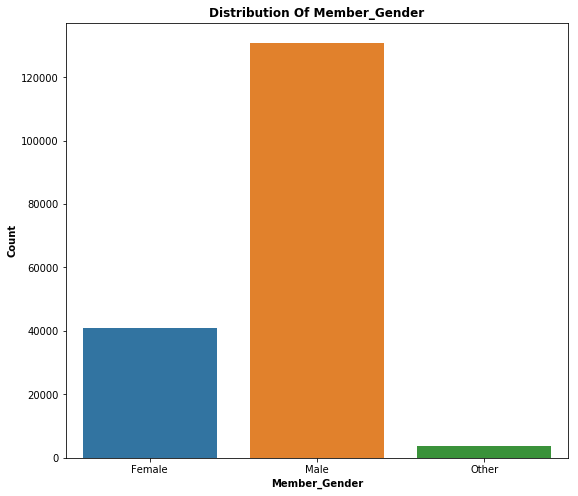

```python
#call the user-defined function to plot the gender distribution
countplot(ford_clean, 'member_gender')
pd.DataFrame(ford_clean['member_gender'].value_counts())
```

#### Observation:

From the chart above, it can be observed that the Male gender makes use of the ford go bike services more than other genders. The count of male that make use of the services is 130651, for female it is 40844, and for other gender, which is has the least count, it is 3652. To me, this means that the male gender are more interested in the bike services than females.

#### Question: What time/hour of the day do people take trips or go on trips more?

[output not shown]

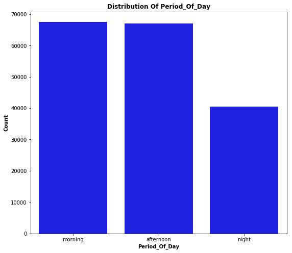

```python
day_hour = ['morning', 'afternoon', 'night']
day_hour_order = pd.api.types.CategoricalDtype(ordered=True, categories=day_hour)
ford_clean['period_of_day'] = ford_clean['period_of_day'].astype(day_hour_order)

countplot(ford_clean, 'period_of_day', color = 'blue')
pd.DataFrame(ford_clean['period_of_day'].value_counts())
```

#### Observation:

It can be observed from the chart above that people tend to take trips in the morning or in the afternoon, rather than at night. This makes sense because it is safer to take trips during the day time that at night fall, and also for people that go to work in the morning. Also, I can also say that maybe some of the riders work at night, because the count of people that ride at night is not so little.

#### Question: Based on user type, who uses the goBike services more?

|  | user_type |
| --- | --- |
| Subscriber | 163544 |
| Customer | 19868 |

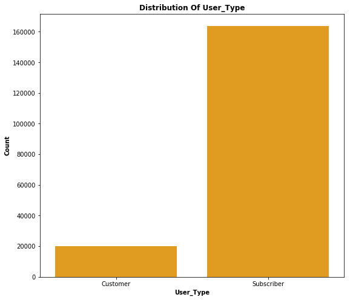

```python
countplot(ford_clean, 'user_type', color = 'orange')
pd.DataFrame(ford_clean['user_type'].value_counts())
```

#### Observation

It can be observed that the people users that are subscribed to the goBike services uses it more than the regular customers. This makes sense, as this is a good thing for the ford goBike company. It also shows that they have more subscribers than regular customers, this may mean that the subscription price is more reasonable that paying for trips everytime. For instance, people would prefer paying a subscription fee of let's say 15 dollars per month, than paying 2 or 3 dollars per trip.

#### Question: What days of the week do riders take trips more?

[output not shown]

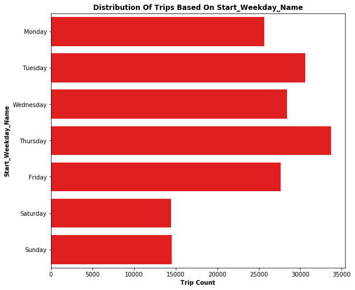

```python
#day of the week riders take trips more
week_day = ['Monday', 'Tuesday', 'Wednesday', 'Thursday', 'Friday', 'Saturday', 'Sunday']
week_day_order = pd.api.types.CategoricalDtype(ordered=True, categories=week_day)
ford_clean['start_weekday_name'] = ford_clean['start_weekday_name'].astype(week_day_order)

countplot2(ford_clean, 'start_weekday_name', color = 'red')
pd.DataFrame(ford_clean['start_weekday_name'].value_counts())
```

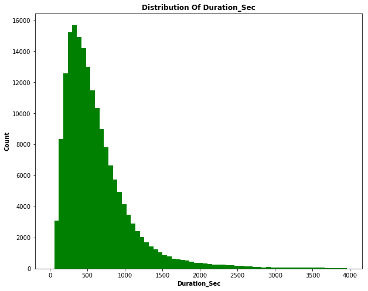

```python
bins = np.arange(0, 4000, 60)
histplot(ford_clean, 'duration_sec', bins=bins, color = 'green')
```

#### Question: What is the Age distribution of members that use the bike services?

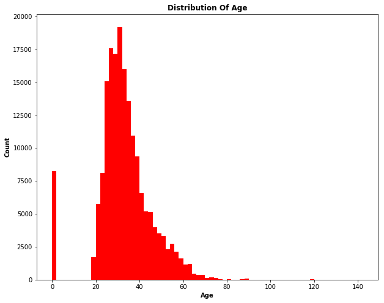

```python
#histogram plot to show the Age distribution
binz = np.arange(0, ford_clean['Age'].max()+2, 2)
histplot(ford_clean, 'Age', bins=binz, color = 'red')
```

```python
#riders that are over 100 years
ford_clean.query('Age > 100')
```

|  | duration_sec | start_time | end_time | start_station_id | start_station_name | start_station_latitude | start_station_longitude | end_station_id | end_station_name | end_station_latitude | ... | member_birth_year | member_gender | bike_share_for_all_trip | start_month_num | start_month_name | start_hour | period_of_day | start_weekday_num | start_weekday_name | Age |
| --- | --- | --- | --- | --- | --- | --- | --- | --- | --- | --- | --- | --- | --- | --- | --- | --- | --- | --- | --- | --- | --- |
| 1285 | 148 | 2019-02-28 19:29:17.627 | 2019-02-28 19:31:45.967 | 158.0 | Shattuck Ave at Telegraph Ave | 37.833279 | -122.263490 | 173.0 | Shattuck Ave at 55th St | 37.840364 | ... | 1900.0 | Male | Yes | 2 | Feb | 19 | night | 3 | Thursday | 119 |
| 10827 | 1315 | 2019-02-27 19:21:34.436 | 2019-02-27 19:43:30.008 | 343.0 | Bryant St at 2nd St | 37.783172 | -122.393572 | 375.0 | Grove St at Masonic Ave | 37.774836 | ... | 1900.0 | Male | No | 2 | Feb | 19 | night | 2 | Wednesday | 119 |
| 16087 | 1131 | 2019-02-27 08:37:36.864 | 2019-02-27 08:56:28.022 | 375.0 | Grove St at Masonic Ave | 37.774836 | -122.446546 | 36.0 | Folsom St at 3rd St | 37.783830 | ... | 1900.0 | Male | No | 2 | Feb | 8 | morning | 2 | Wednesday | 119 |
| 19375 | 641 | 2019-02-26 17:03:19.855 | 2019-02-26 17:14:01.619 | 9.0 | Broadway at Battery St | 37.798572 | -122.400869 | 30.0 | San Francisco Caltrain (Townsend St at 4th St) | 37.776598 | ... | 1900.0 | Male | No | 2 | Feb | 17 | afternoon | 1 | Tuesday | 119 |
| 21424 | 1424 | 2019-02-26 08:58:02.904 | 2019-02-26 09:21:47.749 | 375.0 | Grove St at Masonic Ave | 37.774836 | -122.446546 | 343.0 | Bryant St at 2nd St | 37.783172 | ... | 1900.0 | Male | No | 2 | Feb | 8 | morning | 1 | Tuesday | 119 |
| 21506 | 701 | 2019-02-26 09:06:11.239 | 2019-02-26 09:17:52.442 | 67.0 | San Francisco Caltrain Station 2 (Townsend St... | 37.776639 | -122.395526 | 9.0 | Broadway at Battery St | 37.798572 | ... | 1900.0 | Male | No | 2 | Feb | 9 | morning | 1 | Tuesday | 119 |
| 24042 | 194 | 2019-02-25 18:58:10.644 | 2019-02-25 19:01:25.308 | 158.0 | Shattuck Ave at Telegraph Ave | 37.833279 | -122.263490 | 173.0 | Shattuck Ave at 55th St | 37.840364 | ... | 1900.0 | Male | Yes | 2 | Feb | 18 | night | 0 | Monday | 119 |
| 26133 | 410 | 2019-02-25 13:38:12.067 | 2019-02-25 13:45:02.207 | 173.0 | Shattuck Ave at 55th St | 37.840364 | -122.264488 | 176.0 | MacArthur BART Station | 37.828410 | ... | 1900.0 | Male | Yes | 2 | Feb | 13 | afternoon | 0 | Monday | 119 |
| 27370 | 1474 | 2019-02-25 09:28:42.161 | 2019-02-25 09:53:17.068 | 15.0 | San Francisco Ferry Building (Harry Bridges Pl... | 37.795392 | -122.394203 | 386.0 | 24th St at Bartlett St | 37.752105 | ... | 1878.0 | Female | No | 2 | Feb | 9 | morning | 0 | Monday | 141 |
| 27675 | 1087 | 2019-02-25 09:10:39.549 | 2019-02-25 09:28:46.676 | 375.0 | Grove St at Masonic Ave | 37.774836 | -122.446546 | 36.0 | Folsom St at 3rd St | 37.783830 | ... | 1900.0 | Male | No | 2 | Feb | 9 | morning | 0 | Monday | 119 |
| 29716 | 403 | 2019-02-25 06:46:30.448 | 2019-02-25 06:53:13.914 | 284.0 | Yerba Buena Center for the Arts (Howard St at ... | 37.784872 | -122.400876 | 30.0 | San Francisco Caltrain (Townsend St at 4th St) | 37.776598 | ... | 1901.0 | Male | No | 2 | Feb | 6 | morning | 0 | Monday | 118 |
| 32285 | 299 | 2019-02-24 14:48:50.554 | 2019-02-24 14:53:50.330 | 179.0 | Telegraph Ave at 27th St | 37.816073 | -122.267886 | 195.0 | Bay Pl at Vernon St | 37.812314 | ... | 1900.0 | Female | No | 2 | Feb | 14 | afternoon | 6 | Sunday | 119 |
| 32725 | 85 | 2019-02-24 13:49:52.142 | 2019-02-24 13:51:17.904 | 174.0 | Shattuck Ave at 51st St | 37.836801 | -122.264004 | 173.0 | Shattuck Ave at 55th St | 37.840364 | ... | 1900.0 | Male | Yes | 2 | Feb | 13 | afternoon | 6 | Sunday | 119 |
| 32809 | 395 | 2019-02-24 13:32:43.034 | 2019-02-24 13:39:18.303 | 195.0 | Bay Pl at Vernon St | 37.812314 | -122.260779 | 179.0 | Telegraph Ave at 27th St | 37.816073 | ... | 1900.0 | Female | No | 2 | Feb | 13 | afternoon | 6 | Sunday | 119 |
| 32942 | 169 | 2019-02-24 13:17:05.233 | 2019-02-24 13:19:54.375 | 173.0 | Shattuck Ave at 55th St | 37.840364 | -122.264488 | 174.0 | Shattuck Ave at 51st St | 37.836801 | ... | 1900.0 | Male | Yes | 2 | Feb | 13 | afternoon | 6 | Sunday | 119 |
| 34747 | 180 | 2019-02-23 21:46:26.558 | 2019-02-23 21:49:26.839 | 174.0 | Shattuck Ave at 51st St | 37.836801 | -122.264004 | 204.0 | 55th St at Telegraph Ave | 37.840186 | ... | 1900.0 | Male | Yes | 2 | Feb | 21 | night | 5 | Saturday | 119 |
| 38932 | 389 | 2019-02-23 10:49:33.547 | 2019-02-23 10:56:03.428 | 173.0 | Shattuck Ave at 55th St | 37.840364 | -122.264488 | 150.0 | Adeline St at 40th St | 37.831277 | ... | 1900.0 | Male | Yes | 2 | Feb | 10 | morning | 5 | Saturday | 119 |
| 41194 | 313 | 2019-02-22 18:55:09.207 | 2019-02-22 19:00:22.969 | 340.0 | Harmon St at Adeline St | 37.849735 | -122.270582 | 173.0 | Shattuck Ave at 55th St | 37.840364 | ... | 1900.0 | Male | Yes | 2 | Feb | 18 | night | 4 | Friday | 119 |
| 41246 | 539 | 2019-02-22 18:46:15.403 | 2019-02-22 18:55:15.053 | 30.0 | San Francisco Caltrain (Townsend St at 4th St) | 37.776598 | -122.395282 | 25.0 | Howard St at 2nd St | 37.787522 | ... | 1901.0 | Male | No | 2 | Feb | 18 | night | 4 | Friday | 118 |
| 41319 | 379 | 2019-02-22 18:43:07.018 | 2019-02-22 18:49:26.251 | 173.0 | Shattuck Ave at 55th St | 37.840364 | -122.264488 | 340.0 | Harmon St at Adeline St | 37.849735 | ... | 1900.0 | Male | Yes | 2 | Feb | 18 | night | 4 | Friday | 119 |
| 43880 | 379 | 2019-02-22 15:58:02.725 | 2019-02-22 16:04:22.189 | 39.0 | Scott St at Golden Gate Ave | 37.778999 | -122.436861 | 74.0 | Laguna St at Hayes St | 37.776435 | ... | 1900.0 | Male | No | 2 | Feb | 15 | afternoon | 4 | Friday | 119 |
| 45846 | 1336 | 2019-02-22 10:53:45.889 | 2019-02-22 11:16:02.793 | 74.0 | Laguna St at Hayes St | 37.776435 | -122.426244 | 377.0 | Fell St at Stanyan St | 37.771917 | ... | 1900.0 | Male | No | 2 | Feb | 10 | morning | 4 | Friday | 119 |
| 48804 | 387 | 2019-02-22 07:01:50.431 | 2019-02-22 07:08:18.080 | 284.0 | Yerba Buena Center for the Arts (Howard St at ... | 37.784872 | -122.400876 | 30.0 | San Francisco Caltrain (Townsend St at 4th St) | 37.776598 | ... | 1901.0 | Male | No | 2 | Feb | 7 | morning | 4 | Friday | 118 |
| 58222 | 1055 | 2019-02-21 07:05:11.790 | 2019-02-21 07:22:47.591 | 375.0 | Grove St at Masonic Ave | 37.774836 | -122.446546 | 36.0 | Folsom St at 3rd St | 37.783830 | ... | 1900.0 | Male | No | 2 | Feb | 7 | morning | 3 | Thursday | 119 |
| 60960 | 339 | 2019-02-20 18:08:14.886 | 2019-02-20 18:13:54.858 | 177.0 | MacArthur Blvd at Telegraph Ave | 37.826286 | -122.265100 | 173.0 | Shattuck Ave at 55th St | 37.840364 | ... | 1900.0 | Male | Yes | 2 | Feb | 18 | night | 2 | Wednesday | 119 |
| 61611 | 87 | 2019-02-20 17:41:14.387 | 2019-02-20 17:42:41.909 | 176.0 | MacArthur BART Station | 37.828410 | -122.266315 | 177.0 | MacArthur Blvd at Telegraph Ave | 37.826286 | ... | 1900.0 | Male | Yes | 2 | Feb | 17 | afternoon | 2 | Wednesday | 119 |
| 62598 | 1420 | 2019-02-20 16:27:23.109 | 2019-02-20 16:51:03.781 | 343.0 | Bryant St at 2nd St | 37.783172 | -122.393572 | 375.0 | Grove St at Masonic Ave | 37.774836 | ... | 1900.0 | Male | No | 2 | Feb | 16 | afternoon | 2 | Wednesday | 119 |
| 66700 | 1157 | 2019-02-20 08:22:17.596 | 2019-02-20 08:41:35.430 | 375.0 | Grove St at Masonic Ave | 37.774836 | -122.446546 | 36.0 | Folsom St at 3rd St | 37.783830 | ... | 1900.0 | Male | No | 2 | Feb | 8 | morning | 2 | Wednesday | 119 |
| 72711 | 221 | 2019-02-19 15:58:18.804 | 2019-02-19 16:01:59.839 | 158.0 | Shattuck Ave at Telegraph Ave | 37.833279 | -122.263490 | 173.0 | Shattuck Ave at 55th St | 37.840364 | ... | 1900.0 | Male | Yes | 2 | Feb | 15 | afternoon | 1 | Tuesday | 119 |
| 72819 | 236 | 2019-02-19 15:41:13.029 | 2019-02-19 15:45:09.711 | 176.0 | MacArthur BART Station | 37.828410 | -122.266315 | 158.0 | Shattuck Ave at Telegraph Ave | 37.833279 | ... | 1900.0 | Male | Yes | 2 | Feb | 15 | afternoon | 1 | Tuesday | 119 |
| ... | ... | ... | ... | ... | ... | ... | ... | ... | ... | ... | ... | ... | ... | ... | ... | ... | ... | ... | ... | ... | ... |
| 107359 | 1893 | 2019-02-13 16:00:17.388 | 2019-02-13 16:31:51.002 | 343.0 | Bryant St at 2nd St | 37.783172 | -122.393572 | 375.0 | Grove St at Masonic Ave | 37.774836 | ... | 1900.0 | Male | No | 2 | Feb | 16 | afternoon | 2 | Wednesday | 119 |
| 107619 | 217 | 2019-02-13 15:37:31.735 | 2019-02-13 15:41:09.510 | 158.0 | Shattuck Ave at Telegraph Ave | 37.833279 | -122.263490 | 173.0 | Shattuck Ave at 55th St | 37.840364 | ... | 1900.0 | Male | Yes | 2 | Feb | 15 | afternoon | 2 | Wednesday | 119 |
| 108314 | 1303 | 2019-02-13 08:34:51.645 | 2019-02-13 08:56:34.749 | 375.0 | Grove St at Masonic Ave | 37.774836 | -122.446546 | 36.0 | Folsom St at 3rd St | 37.783830 | ... | 1900.0 | Male | No | 2 | Feb | 8 | morning | 2 | Wednesday | 119 |
| 109010 | 431 | 2019-02-12 20:30:25.977 | 2019-02-12 20:37:37.668 | 215.0 | 34th St at Telegraph Ave | 37.822547 | -122.266318 | 173.0 | Shattuck Ave at 55th St | 37.840364 | ... | 1900.0 | Male | Yes | 2 | Feb | 20 | night | 1 | Tuesday | 119 |
| 110468 | 257 | 2019-02-12 18:00:27.822 | 2019-02-12 18:04:45.246 | 158.0 | Shattuck Ave at Telegraph Ave | 37.833279 | -122.263490 | 215.0 | 34th St at Telegraph Ave | 37.822547 | ... | 1900.0 | Male | Yes | 2 | Feb | 18 | night | 1 | Tuesday | 119 |
| 110734 | 794 | 2019-02-12 17:38:26.377 | 2019-02-12 17:51:40.784 | 173.0 | Shattuck Ave at 55th St | 37.840364 | -122.264488 | 158.0 | Shattuck Ave at Telegraph Ave | 37.833279 | ... | 1900.0 | Male | Yes | 2 | Feb | 17 | afternoon | 1 | Tuesday | 119 |
| 114762 | 543 | 2019-02-12 09:12:25.266 | 2019-02-12 09:21:28.581 | 30.0 | San Francisco Caltrain (Townsend St at 4th St) | 37.776598 | -122.395282 | 26.0 | 1st St at Folsom St | 37.787290 | ... | 1902.0 | Female | No | 2 | Feb | 9 | morning | 1 | Tuesday | 117 |
| 115637 | 1034 | 2019-02-12 08:23:30.357 | 2019-02-12 08:40:44.747 | 375.0 | Grove St at Masonic Ave | 37.774836 | -122.446546 | 36.0 | Folsom St at 3rd St | 37.783830 | ... | 1900.0 | Male | No | 2 | Feb | 8 | morning | 1 | Tuesday | 119 |
| 119010 | 267 | 2019-02-11 18:19:18.848 | 2019-02-11 18:23:46.758 | 158.0 | Shattuck Ave at Telegraph Ave | 37.833279 | -122.263490 | 173.0 | Shattuck Ave at 55th St | 37.840364 | ... | 1900.0 | Male | Yes | 2 | Feb | 18 | night | 0 | Monday | 119 |
| 122194 | 1657 | 2019-02-11 12:19:26.064 | 2019-02-11 12:47:03.298 | 377.0 | Fell St at Stanyan St | 37.771917 | -122.453704 | 36.0 | Folsom St at 3rd St | 37.783830 | ... | 1900.0 | Male | No | 2 | Feb | 12 | afternoon | 0 | Monday | 119 |
| 123240 | 562 | 2019-02-11 09:36:13.876 | 2019-02-11 09:45:36.806 | 30.0 | San Francisco Caltrain (Townsend St at 4th St) | 37.776598 | -122.395282 | 26.0 | 1st St at Folsom St | 37.787290 | ... | 1902.0 | Female | No | 2 | Feb | 9 | morning | 0 | Monday | 117 |
| 128986 | 520 | 2019-02-10 11:48:51.152 | 2019-02-10 11:57:31.632 | 173.0 | Shattuck Ave at 55th St | 37.840364 | -122.264488 | 150.0 | Adeline St at 40th St | 37.831277 | ... | 1900.0 | Male | Yes | 2 | Feb | 11 | morning | 6 | Sunday | 119 |
| 137804 | 372 | 2019-02-08 08:22:24.741 | 2019-02-08 08:28:37.126 | 30.0 | San Francisco Caltrain (Townsend St at 4th St) | 37.776598 | -122.395282 | 26.0 | 1st St at Folsom St | 37.787290 | ... | 1902.0 | Female | No | 2 | Feb | 8 | morning | 4 | Friday | 117 |
| 138297 | 491 | 2019-02-08 07:44:39.461 | 2019-02-08 07:52:51.140 | 284.0 | Yerba Buena Center for the Arts (Howard St at ... | 37.784872 | -122.400876 | 30.0 | San Francisco Caltrain (Townsend St at 4th St) | 37.776598 | ... | 1901.0 | Male | No | 2 | Feb | 7 | morning | 4 | Friday | 118 |
| 140748 | 481 | 2019-02-07 18:41:11.650 | 2019-02-07 18:49:13.254 | 25.0 | Howard St at 2nd St | 37.787522 | -122.397405 | 30.0 | San Francisco Caltrain (Townsend St at 4th St) | 37.776598 | ... | 1902.0 | Female | No | 2 | Feb | 18 | night | 3 | Thursday | 117 |
| 145510 | 508 | 2019-02-07 09:34:11.542 | 2019-02-07 09:42:40.400 | 30.0 | San Francisco Caltrain (Townsend St at 4th St) | 37.776598 | -122.395282 | 26.0 | 1st St at Folsom St | 37.787290 | ... | 1902.0 | Female | No | 2 | Feb | 9 | morning | 3 | Thursday | 117 |
| 147519 | 460 | 2019-02-07 07:44:28.217 | 2019-02-07 07:52:08.390 | 284.0 | Yerba Buena Center for the Arts (Howard St at ... | 37.784872 | -122.400876 | 30.0 | San Francisco Caltrain (Townsend St at 4th St) | 37.776598 | ... | 1901.0 | Male | No | 2 | Feb | 7 | morning | 3 | Thursday | 118 |
| 150108 | 727 | 2019-02-06 18:24:40.310 | 2019-02-06 18:36:48.183 | 81.0 | Berry St at 4th St | 37.775880 | -122.393170 | 284.0 | Yerba Buena Center for the Arts (Howard St at ... | 37.784872 | ... | 1910.0 | Other | No | 2 | Feb | 18 | night | 2 | Wednesday | 109 |
| 151936 | 622 | 2019-02-06 16:42:11.928 | 2019-02-06 16:52:34.230 | 25.0 | Howard St at 2nd St | 37.787522 | -122.397405 | 30.0 | San Francisco Caltrain (Townsend St at 4th St) | 37.776598 | ... | 1902.0 | Female | No | 2 | Feb | 16 | afternoon | 2 | Wednesday | 117 |
| 161505 | 355 | 2019-02-05 14:43:59.227 | 2019-02-05 14:49:54.267 | 25.0 | Howard St at 2nd St | 37.787522 | -122.397405 | 30.0 | San Francisco Caltrain (Townsend St at 4th St) | 37.776598 | ... | 1902.0 | Female | No | 2 | Feb | 14 | afternoon | 1 | Tuesday | 117 |
| 162051 | 176 | 2019-02-05 13:00:00.604 | 2019-02-05 13:02:57.549 | 173.0 | Shattuck Ave at 55th St | 37.840364 | -122.264488 | 174.0 | Shattuck Ave at 51st St | 37.836801 | ... | 1900.0 | Male | Yes | 2 | Feb | 13 | afternoon | 1 | Tuesday | 119 |
| 163112 | 1640 | 2019-02-05 09:18:18.397 | 2019-02-05 09:45:39.016 | 377.0 | Fell St at Stanyan St | 37.771917 | -122.453704 | 36.0 | Folsom St at 3rd St | 37.783830 | ... | 1900.0 | Male | No | 2 | Feb | 9 | morning | 1 | Tuesday | 119 |
| 167178 | 526 | 2019-02-04 17:36:54.155 | 2019-02-04 17:45:41.140 | 25.0 | Howard St at 2nd St | 37.787522 | -122.397405 | 30.0 | San Francisco Caltrain (Townsend St at 4th St) | 37.776598 | ... | 1902.0 | Female | No | 2 | Feb | 17 | afternoon | 0 | Monday | 117 |
| 171086 | 1086 | 2019-02-04 06:30:33.383 | 2019-02-04 06:48:39.869 | 375.0 | Grove St at Masonic Ave | 37.774836 | -122.446546 | 36.0 | Folsom St at 3rd St | 37.783830 | ... | 1900.0 | Male | No | 2 | Feb | 6 | morning | 0 | Monday | 119 |
| 171757 | 94 | 2019-02-03 19:12:06.607 | 2019-02-03 19:13:40.671 | 173.0 | Shattuck Ave at 55th St | 37.840364 | -122.264488 | 174.0 | Shattuck Ave at 51st St | 37.836801 | ... | 1900.0 | Male | Yes | 2 | Feb | 19 | night | 6 | Sunday | 119 |
| 171996 | 1368 | 2019-02-03 17:33:54.607 | 2019-02-03 17:56:42.949 | 37.0 | 2nd St at Folsom St | 37.785000 | -122.395936 | 375.0 | Grove St at Masonic Ave | 37.774836 | ... | 1900.0 | Male | No | 2 | Feb | 17 | afternoon | 6 | Sunday | 119 |
| 173711 | 993 | 2019-02-03 09:45:30.464 | 2019-02-03 10:02:04.169 | 375.0 | Grove St at Masonic Ave | 37.774836 | -122.446546 | 36.0 | Folsom St at 3rd St | 37.783830 | ... | 1900.0 | Male | No | 2 | Feb | 9 | morning | 6 | Sunday | 119 |
| 177708 | 1527 | 2019-02-01 19:09:28.387 | 2019-02-01 19:34:55.963 | 343.0 | Bryant St at 2nd St | 37.783172 | -122.393572 | 375.0 | Grove St at Masonic Ave | 37.774836 | ... | 1900.0 | Male | No | 2 | Feb | 19 | night | 4 | Friday | 119 |
| 177885 | 517 | 2019-02-01 18:38:40.471 | 2019-02-01 18:47:18.392 | 25.0 | Howard St at 2nd St | 37.787522 | -122.397405 | 30.0 | San Francisco Caltrain (Townsend St at 4th St) | 37.776598 | ... | 1902.0 | Female | No | 2 | Feb | 18 | night | 4 | Friday | 117 |
| 182830 | 428 | 2019-02-01 07:45:05.934 | 2019-02-01 07:52:14.922 | 284.0 | Yerba Buena Center for the Arts (Howard St at ... | 37.784872 | -122.400876 | 67.0 | San Francisco Caltrain Station 2 (Townsend St... | 37.776639 | ... | 1901.0 | Male | No | 2 | Feb | 7 | morning | 4 | Friday | 118 |

72 rows × 23 columns

```python
#drop Age values greater than 100 and values equal to 0
ford_clean.drop(ford_clean[ford_clean['Age'] > 100 ].index, inplace = True)
ford_clean.drop(ford_clean[ford_clean['Age'] <= 0 ].index, inplace = True)
```

```python
ford_clean['Age'].describe()
```

```
count    175075.000000
mean         34.158778
std           9.972079
min          18.000000
25%          27.000000
50%          32.000000
75%          39.000000
max          99.000000
Name: Age, dtype: float64
```

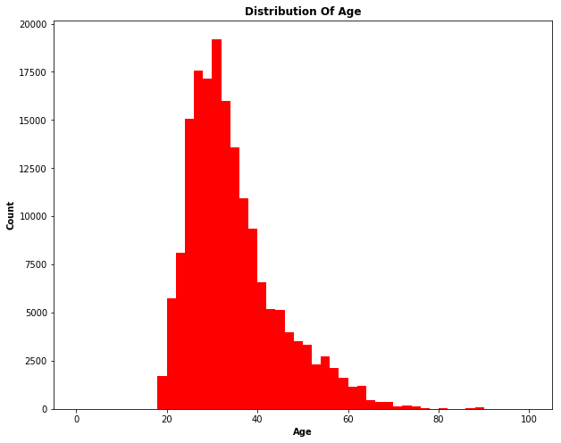

```python
#confirm results
binz = np.arange(0, ford_clean['Age'].max()+2, 2)
histplot(ford_clean, 'Age', bins=binz, color = 'red')
```

#### Observation

I observed that most riders are around the ages of 25 to 31 years old. There are also riders that are above the age of 100, that are even 141 years old, as that is the maximum age. I viewed these ages as very high outliers and i also got rid of the 0 age, which was as a result of filling the null values in the Age column to 0. The actual minimum age is 18.

#### Question: What stations have the most trips?

|  | start_station_name |
| --- | --- |
| Market St at 10th St | 3649 |
| San Francisco Caltrain Station 2 (Townsend St at 4th St) | 3406 |
| Berry St at 4th St | 2951 |
| Montgomery St BART Station (Market St at 2nd St) | 2711 |
| Powell St BART Station (Market St at 4th St) | 2620 |
| San Francisco Caltrain (Townsend St at 4th St) | 2572 |
| San Francisco Ferry Building (Harry Bridges Plaza) | 2540 |
| Howard St at Beale St | 2216 |
| Steuart St at Market St | 2191 |
| Powell St BART Station (Market St at 5th St) | 2144 |

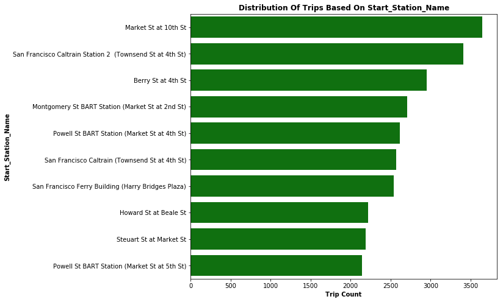

```python
#I am going to create a plot of the top 10 stations (start_stations)with most trips
top_stations = ford_clean['start_station_name'].value_counts().index[:10]
countplot2(ford_clean, 'start_station_name', color = 'green', order = top_stations)
pd.DataFrame(ford_clean['start_station_name'].value_counts().head(10))
```

|  | end_station_name |
| --- | --- |
| San Francisco Caltrain Station 2 (Townsend St at 4th St) | 4622 |
| Market St at 10th St | 3709 |
| Montgomery St BART Station (Market St at 2nd St) | 3461 |
| San Francisco Ferry Building (Harry Bridges Plaza) | 3151 |
| San Francisco Caltrain (Townsend St at 4th St) | 2860 |
| Powell St BART Station (Market St at 4th St) | 2854 |
| Berry St at 4th St | 2782 |
| The Embarcadero at Sansome St | 2341 |
| Steuart St at Market St | 2264 |
| Powell St BART Station (Market St at 5th St) | 2153 |

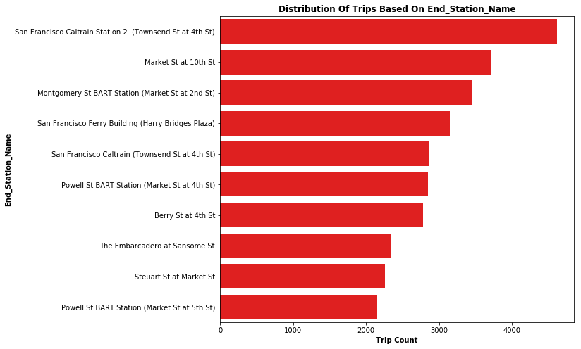

```python
#top 10 end_stations with most arrivals
top_end_stations = ford_clean['end_station_name'].value_counts().index[:10]
countplot2(ford_clean, 'end_station_name', color = 'red', order = top_end_stations)
pd.DataFrame(ford_clean['end_station_name'].value_counts().head(10))
```

```python
ford_clean.info()
```

[output not shown]

#### Observation

From the plots above, most stations begin and end at Market St at 10th St and San Francisco Caltrain station2. This may mean that people prefer using these routes for their trips, probably because their start and final destinations are closer to these stations. It is just an assumption. There might be other factors involved that make these stations have the highest number of trips (start and end). This may be looked into.

### Discuss the distribution(s) of your variable(s) of interest. Were there any unusual points? Did you need to perform any transformations?

> Yes, I performed some transformations on the Age column that was added. The hist plot for Age was skewed to the right, as there were ages that were over 100. I decided to remove those Ages that were greater than age 100 and also ages that were equal to 0 which were null values. I had to perform these transformations to have a clearer view of the age distribution, and for it to be somewhat evenly distributed because there were no much riders who were older than 100 also.

## Bivariate Exploration

#### Question: How much trips do stations make based on hour of the day and day of the week?

```
Text(0.5,1,'Trip count of top 10 start stations based on hour of the day')
```

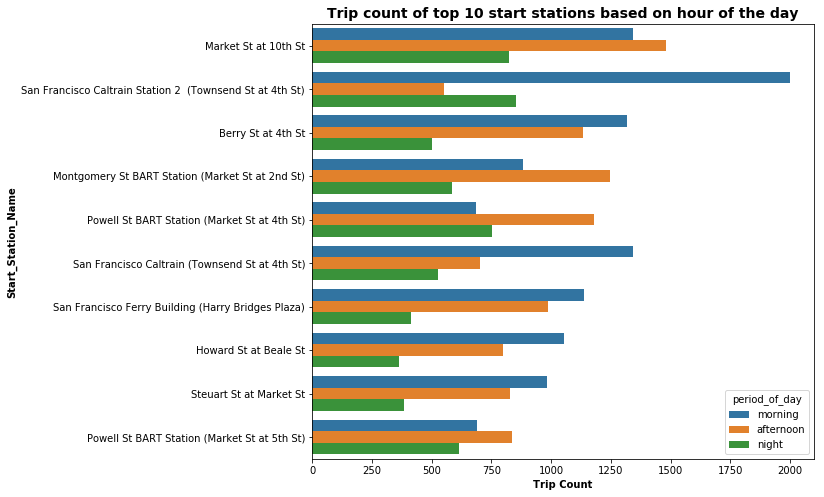

```python
#hour of the day
top_start_stations = ford_clean['start_station_name'].value_counts().index[:10]
bivariate(ford_clean, 'start_station_name', order=top_start_stations, hue='period_of_day')
plt.title("Trip count of top 10 start stations based on hour of the day", fontsize=14, weight='bold')
```

```
Text(0.5,1,'Trip count of top 10 start stations based on day of the week')
```

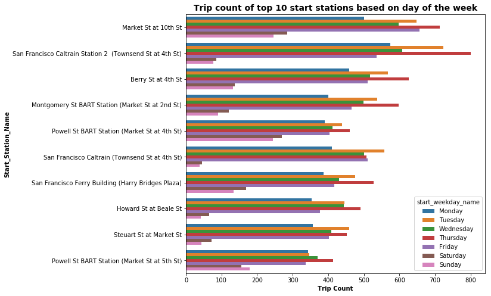

```python
#day of the week
top_start_stations = ford_clean['start_station_name'].value_counts().index[:10]
bivariate(ford_clean, 'start_station_name', order=top_start_stations, hue='start_weekday_name')
plt.title("Trip count of top 10 start stations based on day of the week", fontsize=14, weight='bold')
```

#### Question: What is the trip count in stations based on gender and user type?

```
Text(0.5,1,'Trip count of top 10 start stations based on gender')
```

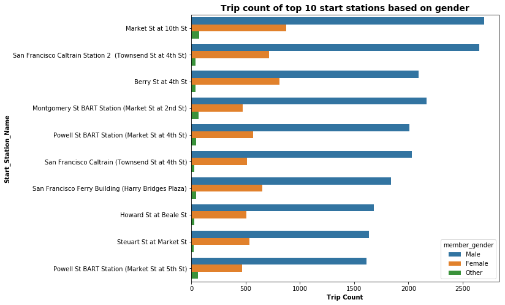

```python
#gender
gender = ['Male', 'Female', 'Other']
gender_order = pd.api.types.CategoricalDtype(ordered=True, categories=gender)
ford_clean['member_gender'] = ford_clean['member_gender'].astype(gender_order)

top_start_stations = ford_clean['start_station_name'].value_counts().index[:10]
bivariate(ford_clean, 'start_station_name', order=top_start_stations, hue='member_gender')
plt.title("Trip count of top 10 start stations based on gender", fontsize=14, weight='bold')
```

```
Text(0.5,1,'Trip count of top 10 start stations based on user type')
```

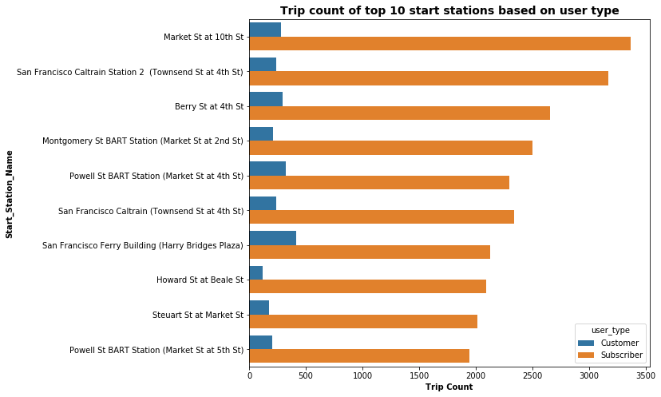

```python
#user type
top_start_stations = ford_clean['start_station_name'].value_counts().index[:10]
bivariate(ford_clean, 'start_station_name', order=top_start_stations, hue='user_type')
plt.title("Trip count of top 10 start stations based on user type", fontsize=14, weight='bold')
```

#### Observations

1. In the top 10 stations, the Male gender takes more trips than the other genders. Although, I do not know where the "Other" gender falls into, I would assume they are people who did not reveal their gender. It should be looked into as to why men take more trips than women. It may be that some women do not want to use bikes for their trips due to comfort. That is my opinion
2. In the second plot, subscribers are the ones that take most trips in all the top 10 stations. The customers that take trips in these stations are few. These customers might be tourists and the subscribers might be residents of San Francisco who make use of the bike services daily or weekly.

#### Question: What is the duration of trips from each station?(Top 10)

```
Text(0.5,1,'Distribution of trips durations in Top 10 stations')
```

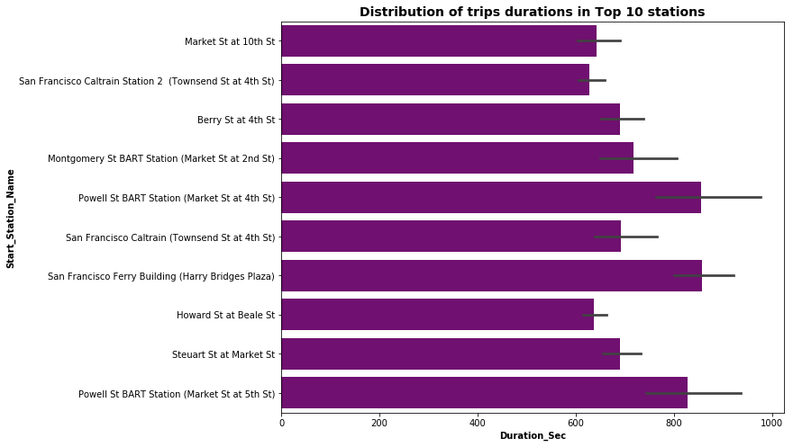

```python
top_start_stations = ford_clean['start_station_name'].value_counts().index[:10]
barplots(ford_clean, 'start_station_name', x = 'duration_sec', color = 'purple', order=top_start_stations)
plt.title('Distribution of trips durations in Top 10 stations', fontsize=14, weight='bold')
```

#### Observation

San Francisco Ferry Building and Powell St Bart station at 4th street have the highest duration of trips, which is over 800 secs and if converted to minutes is about 14 minutes. This means that rides taken from these stations takes about 14 minutes to get to their destinations. San Francisco Caltrain station has the shortest duration of trip which is about 600 secs, when converted is about 10 minutes there about. Rides from these station takes a min of 10 minutes, pending on the destination station.

### Talk about some of the relationships you observed in this part of the investigation. How did the feature(s) of interest vary with other features in the dataset?

I observed the relationships of user type based on number of trips in the top 10 stations. I saw that subscribers have more trips in the stations than customers. This made me conclude that customers may be tourists. I also checked the count of trips in the top 10 stations based on hour of the day and day of the week and saw that most trips occur in the mornings in some stations and also most trips occur during weekdays. Male gender also seem to take more trips in all the stations than the female gender

### Did you observe any interesting relationships between the other features (not the main feature(s) of interest)?

I observed the duration of trips in the top 10 stations. I saw that the highest duration of trip takes about 14 minutes in one station and the least duration of trip in another station takes about 10 minutes

## Multivariate Exploration

#### Question: What is the count of trips taken by both customers and subscribers during the week in the top 10 stations?

```python
#separate user types
ford_cust = ford_clean.query('user_type == "Customer"')

ford_sub = ford_clean.query('user_type == "Subscriber"')
```

```
Text(0.5,1,'Top 10 stations with count of Customers trips based on day of the week')
```

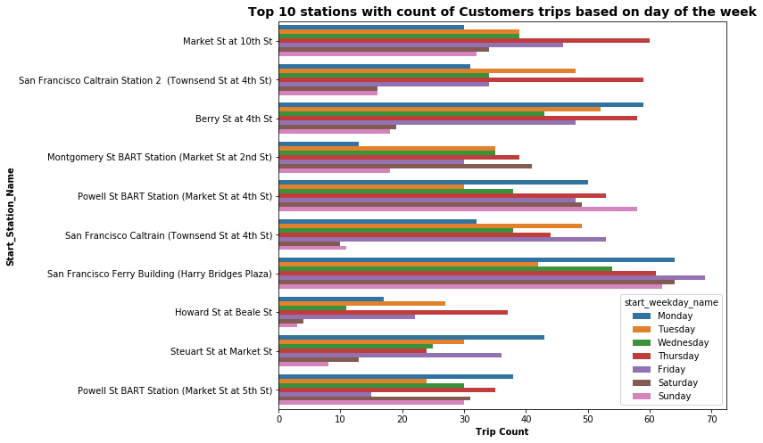

```python
#day of the week trips of Customers
top_start_stations = ford_clean['start_station_name'].value_counts().index[:10]
bivariate(ford_cust, 'start_station_name', order=top_start_stations, hue='start_weekday_name')
plt.title("Top 10 stations with count of Customers trips based on day of the week", fontsize=14,weight='bold')
```

```
Text(0.5,1,'Top 10 stations with count of Subscribers trips based on day of the week')
```

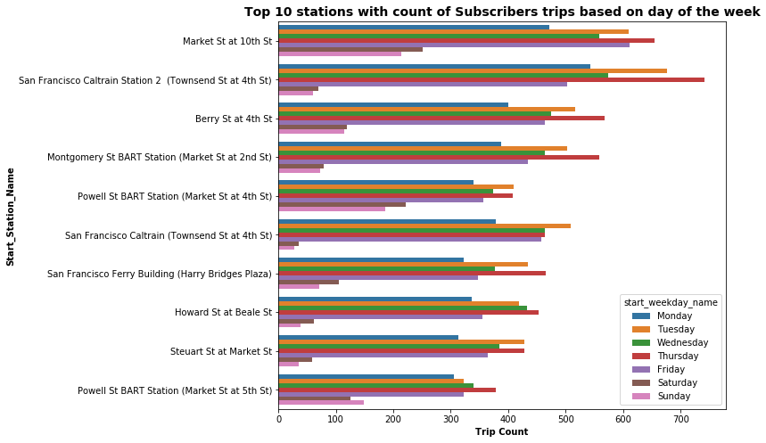

```python
#day of the week trips of Subscribers
top_start_stations = ford_clean['start_station_name'].value_counts().index[:10]
bivariate(ford_sub, 'start_station_name', order=top_start_stations, hue='start_weekday_name')
plt.title("Top 10 stations with count of Subscribers trips based on day of the week", fontsize=14,weight='bold')
```

#### Question: What is the count of trips taken by the male and female genders of the top 10 stations weekly and hourly?

```python
#separate gender types
ford_male = ford_clean.query('member_gender == "Male"')

ford_female = ford_clean.query('member_gender == "Female"')
```

```
Text(0.5,1,'Top 10 stations with count of Male trips based on hour of the day')
```

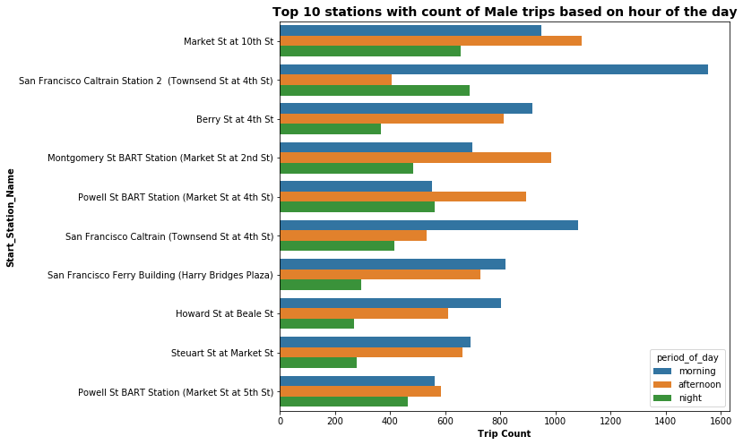

```python
#hour of the day trips of Males
top_start_stations = ford_clean['start_station_name'].value_counts().index[:10]
bivariate(ford_male, 'start_station_name', order=top_start_stations, hue='period_of_day')
plt.title("Top 10 stations with count of Male trips based on hour of the day", fontsize=14,weight='bold')
```

```
Text(0.5,1,'Top 10 stations with count of Female trips based on hour of the day')
```

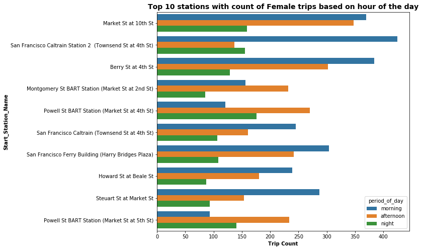

```python
#hour of the day trips of females
top_start_stations = ford_clean['start_station_name'].value_counts().index[:10]
bivariate(ford_female, 'start_station_name', order=top_start_stations, hue='period_of_day')
plt.title("Top 10 stations with count of Female trips based on hour of the day", fontsize=14,weight='bold')
```

```
Text(0.5,1,'Top 10 stations with count of Female trips based on day of the week')
```

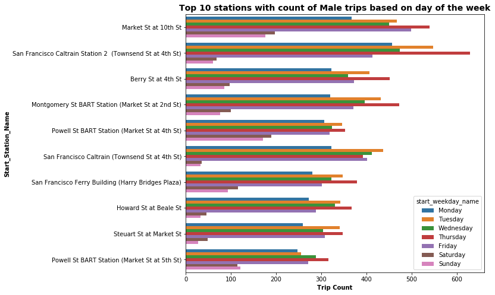

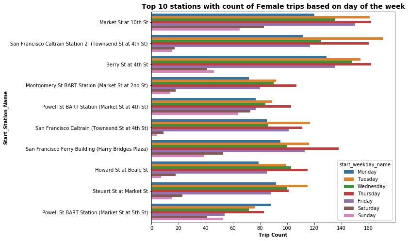

```python
#during the week for Males
top_start_stations = ford_clean['start_station_name'].value_counts().index[:10]
bivariate(ford_male, 'start_station_name', order=top_start_stations, hue='start_weekday_name')
plt.title("Top 10 stations with count of Male trips based on day of the week", fontsize=14,weight='bold')

#during the week for females
top_start_stations = ford_clean['start_station_name'].value_counts().index[:10]
bivariate(ford_female, 'start_station_name', order=top_start_stations, hue='start_weekday_name')
plt.title("Top 10 stations with count of Female trips based on day of the week", fontsize=14,weight='bold')
```

#### Observation

It was observed that males and females take most trips in the mornings and also from Monday to friday. Although,it is quite hard to tell any distinct trends between both gengers.

#### Question: What is the duration of trips from the start stations based on hour of the day and day of the week?

```
Text(0.5,1,'Duration of trips from start stations based on day of the week')
```

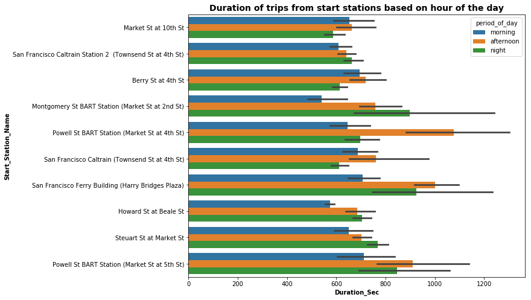

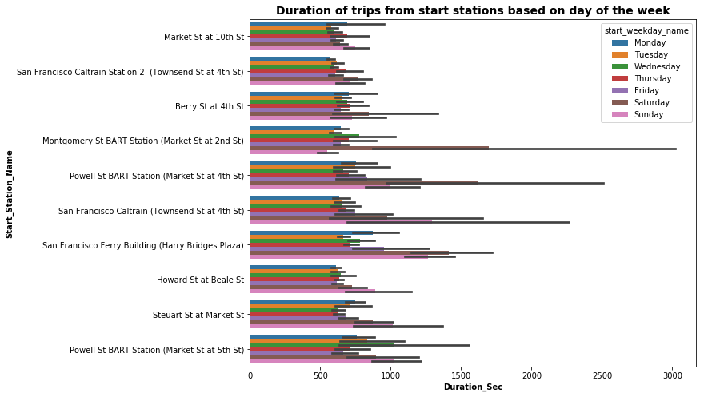

```python
#hour of the day
top_start_stations = ford_clean['start_station_name'].value_counts().index[:10]
barplots(ford_clean, 'start_station_name', x = 'duration_sec', hue='period_of_day', order=top_start_stations)
plt.title('Duration of trips from start stations based on hour of the day', fontsize=14, weight='bold')

#day of the week
top_start_stations = ford_clean['start_station_name'].value_counts().index[:10]
barplots(ford_clean, 'start_station_name', x = 'duration_sec', hue='start_weekday_name', order=top_start_stations)
plt.title('Duration of trips from start stations based on day of the week', fontsize=14, weight='bold')
```

#### Observation

In some stations, trips are longer in the afternoon and at night than in the morning. In the second plot, it is seen that trips are longer during the weekends in some stations.

### Were there any interesting or surprising interactions between features?

> I was quite surprised that most stations trips are longer in the afternoon and at night. It may mean that passengers tend to go to farther locations at the times of the day or the bikes tend to drive slower, especially at night, to ensure a safe trip.

## Conclusions

In this data visualization analysis, I carried out exploratory data analysis by investigating a dataset called Ford GoBike share 2019. I carried out some cleaning and tidying in the data, like incorrect datatypes and adding additional columns to help with more insight. I also investigated the relationships between several variables in the datatset. I performed Univariate explorations, Bivariate explorations and Multivariate explorations. I observed in the dataset that there were riders above the age of 100, and also that most riders were males. I also observed that most stations had more subscribers than customers, and that the duration of most stations trips were in the afternoon and at night.

This analysis unveiled several relationships between variables and gave so much insight into the dataset